# Hotel Bookings EDA

Sergio Puno

2/23/2022

# Preparations

Below are the required packages used if you’d like to reproduce the results. The full source code is available at [my github repository](https://github.com/Sergio-Puno).

## Load libraries

Libraries for data wrangling, general visualization and extra specialized tools.

```r
# data manipulation
library(tidyverse)
library(tidytuesdayR)
library(lubridate)
library(tidytext)
library(rlang)

# visualization
library(ggplot2)
library(scales)

# forecast

# formatting
library(kableExtra)
```

## Helper functions

First create functions that can help with some plotting to reduce repeated code chunks.

```r
# quick histogram plotting with median feed-in
plot_distribution <- function(df, feature, x_intercept) {
  x <- ggplot(data = df, aes(x = {{feature}})) +
    geom_histogram(fill = "steelblue3") +
    geom_vline(xintercept = as.double(x_intercept), color = "red")

  return(x)
}

# quick bar plot for univariate analysis
plot_bar <- function(df, feature, agg_n) {
  x <- ggplot(data = df, aes(x = {{agg_n}}, y = {{feature}}, fill = {{feature}})) +
    geom_col() +
    theme(legend.position="none")

  return(x)
}
```

## Load data

Import file from TidyTuesday repo and local country abbreviations cross reference csv.

```r
hotels <- readr::read_csv('https://raw.githubusercontent.com/rfordatascience/tidytuesday/master/data/2020/2020-02-11/hotels.csv')

country_codes <- read_csv("country_codes.csv")

head(hotels)
```

| hotel | is_canceled | lead_time | arrival_date_year | arrival_date_month | arrival_date_week_number | arrival_date_day_of_month | stays_in_weekend_nights | stays_in_week_nights | adults | children | babies | meal | country | market_segment | distribution_channel | is_repeated_guest | previous_cancellations | previous_bookings_not_canceled | reserved_room_type | assigned_room_type | booking_changes | deposit_type | agent | company | days_in_waiting_list | customer_type | adr | required_car_parking_spaces | total_of_special_requests | … |
| --- | --- | --- | --- | --- | --- | --- | --- | --- | --- | --- | --- | --- | --- | --- | --- | --- | --- | --- | --- | --- | --- | --- | --- | --- | --- | --- | --- | --- | --- | --- |
| Resort Hotel | 0 | 342 | 2015 | July | 27 | 1 | 0 | 0 | 2 | 0 | 0 | BB | PRT | Direct | Direct | 0 | 0 | 0 | C | C | 3 | No Deposit | NULL | NULL | 0 | Transient | 0 | 0 | 0 | … |
| Resort Hotel | 0 | 737 | 2015 | July | 27 | 1 | 0 | 0 | 2 | 0 | 0 | BB | PRT | Direct | Direct | 0 | 0 | 0 | C | C | 4 | No Deposit | NULL | NULL | 0 | Transient | 0 | 0 | 0 | … |
| Resort Hotel | 0 | 7 | 2015 | July | 27 | 1 | 0 | 1 | 1 | 0 | 0 | BB | GBR | Direct | Direct | 0 | 0 | 0 | A | C | 0 | No Deposit | NULL | NULL | 0 | Transient | 75 | 0 | 0 | … |
| Resort Hotel | 0 | 13 | 2015 | July | 27 | 1 | 0 | 1 | 1 | 0 | 0 | BB | GBR | Corporate | Corporate | 0 | 0 | 0 | A | A | 0 | No Deposit | 304 | NULL | 0 | Transient | 75 | 0 | 0 | … |
| Resort Hotel | 0 | 14 | 2015 | July | 27 | 1 | 0 | 2 | 2 | 0 | 0 | BB | GBR | Online TA | TA/TO | 0 | 0 | 0 | A | A | 0 | No Deposit | 240 | NULL | 0 | Transient | 98 | 0 | 1 | … |
| Resort Hotel | 0 | 14 | 2015 | July | 27 | 1 | 0 | 2 | 2 | 0 | 0 | BB | GBR | Online TA | TA/TO | 0 | 0 | 0 | A | A | 0 | No Deposit | 240 | NULL | 0 | Transient | 98 | 0 | 1 | … |

# Data Background

This information comes from two datasets of hotel demand data, one a resort hotel in the region of Algarve and the other a city hotel in the region of Lisbon (both in Portugal).

The brief associated with this data can be found [here](https://www.sciencedirect.com/science/article/pii/S2352340918315191#f0010). One consideration mentioned in this briefing was the below:

*“…even though the capture of data took considered a timespan prior to arrival date, it is understandable that the distribution of some variables differ between non canceled and canceled bookings.”*

We’ll have to consider the impact of a cancelled booking on each distribution and how a cancelled booking is different (on average) compared to a booking that showed up.

# Data Cleaning / Prelimary Analysis

## Missing Values

Quick missing values check to see if there are any massive holes in the data:

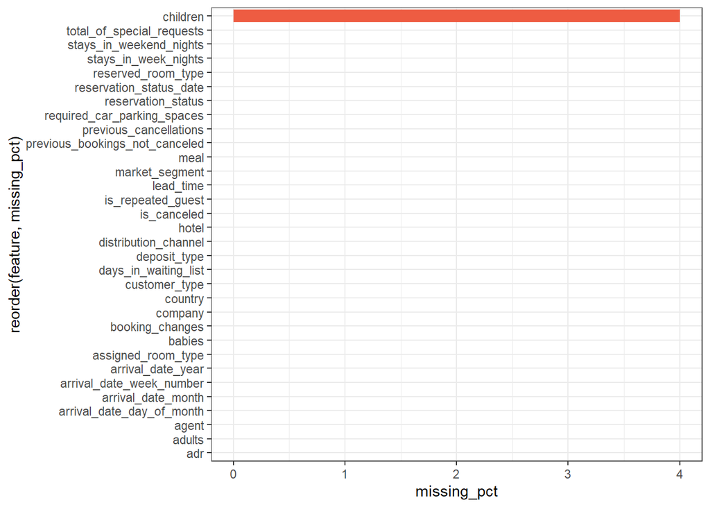

```r
# checking for missing values
missing_values <- hotels %>%
  summarise(across(everything(), ~sum(is.na(.))))

missing_values <- gather(missing_values, key = "feature", value = "missing_pct")

missing_values %>%
  ggplot(aes(x = reorder(feature, missing_pct), y = missing_pct)) +
  geom_bar(stat = "identity", fill = "tomato2") +
  coord_flip() +
  theme_bw()
```

### Creating/Updating data fields

Generating any new fields/columns that I feel may be helpful in subsequent analysis as well as changing some data types from the initial import such as converting certain fields to factors.

```r
# creating a new date column with the year/month/day of month cols for arrivals
hotels <- hotels %>%
  mutate(arrival_date = dmy(paste(arrival_date_day_of_month,
                                  arrival_date_month,
                                  arrival_date_year,
                                  sep = "-"))) %>%
  mutate(is_canceled = as.factor(is_canceled),
         stays_in_weekend_nights = as.factor(stays_in_weekend_nights),
         stays_in_week_nights = as.factor(stays_in_week_nights),
         meal = as.factor(meal),
         market_segment = as.factor(market_segment),
         distribution_channel = as.factor(distribution_channel),
         reserved_room_type = as.factor(reserved_room_type),
         assigned_room_type = as.factor(assigned_room_type),
         deposit_type = as.factor(deposit_type),
         customer_type = as.factor(customer_type),
         reservation_status = as.factor(reservation_status))
```

## Univariate Analysis

Distributions and getting to know our data

### Market Segments

Checking most common segments that drive bookings

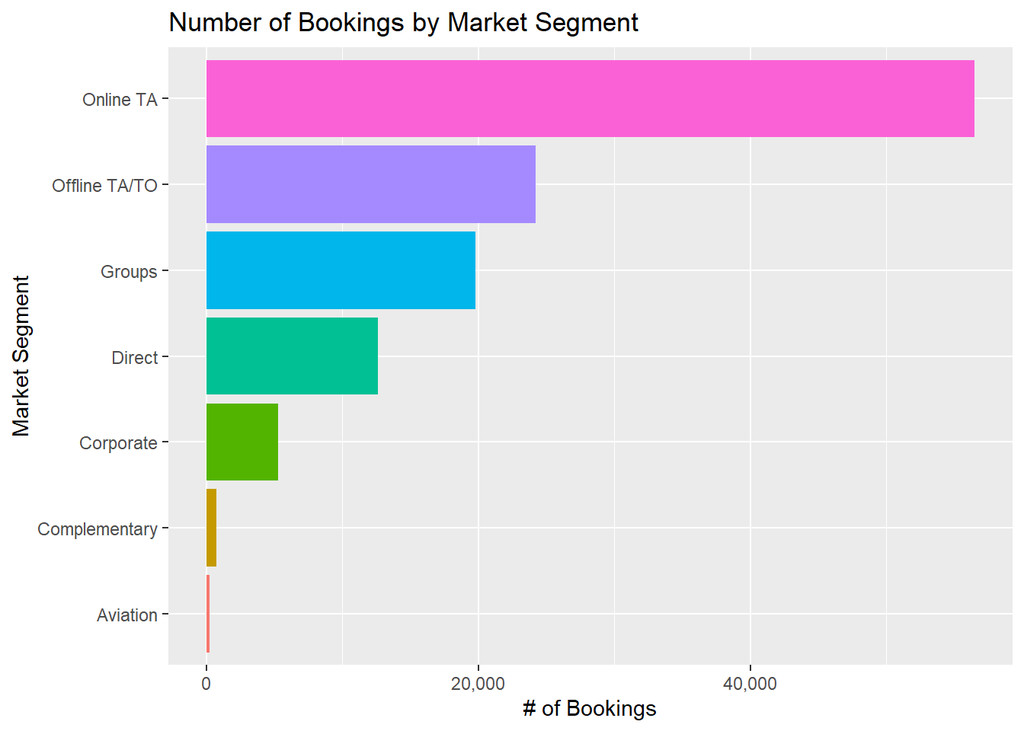

```r
hotels %>%
  filter(market_segment != "Undefined") %>%
  count(market_segment, sort= TRUE) %>%
  plot_bar(., market_segment, n) +
  labs(x = "# of Bookings", y = "Market Segment",
       title = "Number of Bookings by Market Segment") +
  scale_x_continuous(labels = comma)
```

```r
hotels %>%
  count(market_segment, sort = TRUE)
```

| market_segment | n |
| --- | --- |
| Online TA | 56477 |
| Offline TA/TO | 24219 |
| Groups | 19811 |
| Direct | 12606 |
| Corporate | 5295 |
| Complementary | 743 |
| Aviation | 237 |
| Undefined | 2 |

### Countries of visitors

Identifying most common customer country of origin, bringing in full country name from the helper file I loaded in for country abbreviations.

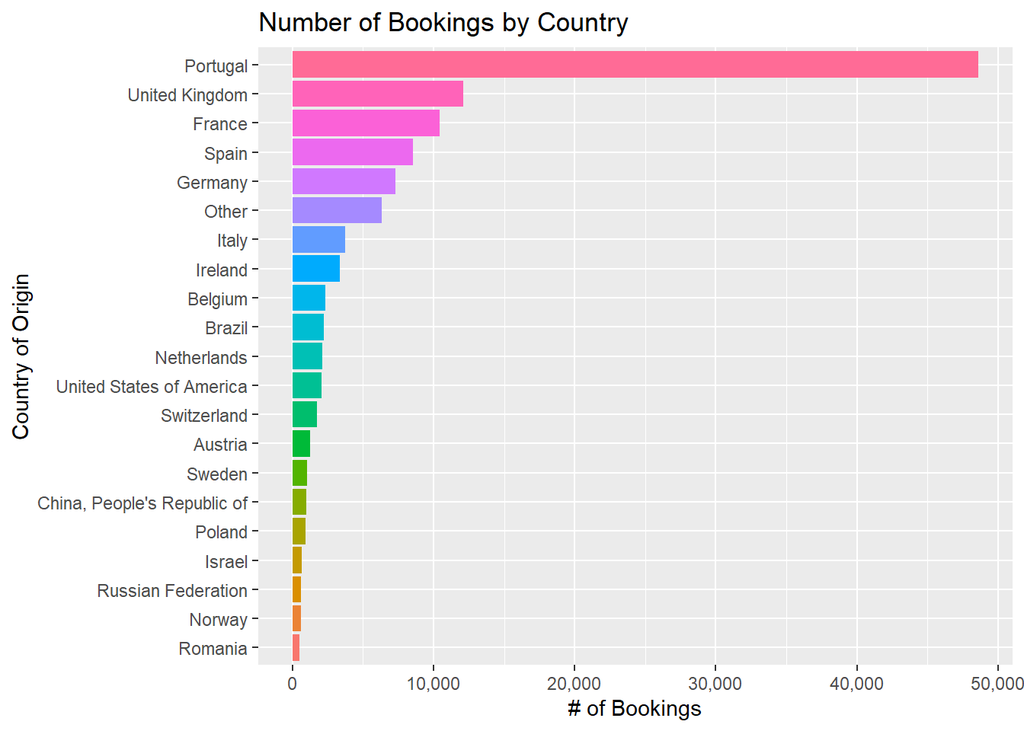

```r
hotels %>%
  left_join(., country_codes, by = "country") %>%
  filter(!is.na(country_name)) %>%
  mutate(country_name = fct_lump(country_name, 20)) %>%
  count(country_name, sort= TRUE) %>%
  mutate(country_name = fct_reorder(country_name, n)) %>%
  plot_bar(., country_name, n) +
  labs(x = "# of Bookings", y = "Country of Origin",
       title = "Number of Bookings by Country") +
  scale_x_continuous(labels = comma)
```

```r
hotels %>%
  count(country, sort= TRUE)
```

| country | n |
| --- | --- |
| PRT | 48590 |
| GBR | 12129 |
| FRA | 10415 |
| ESP | 8568 |
| DEU | 7287 |
| ITA | 3766 |
| IRL | 3375 |
| BEL | 2342 |
| BRA | 2224 |
| NLD | 2104 |

[output cut: 168 more lines]

### Customer Type

What is the most common customer type, we can study this in combination with other details we have such as `reserved_room_type` or `deposit_Type` to see if certain types of customers are aligned with certain other requirements.

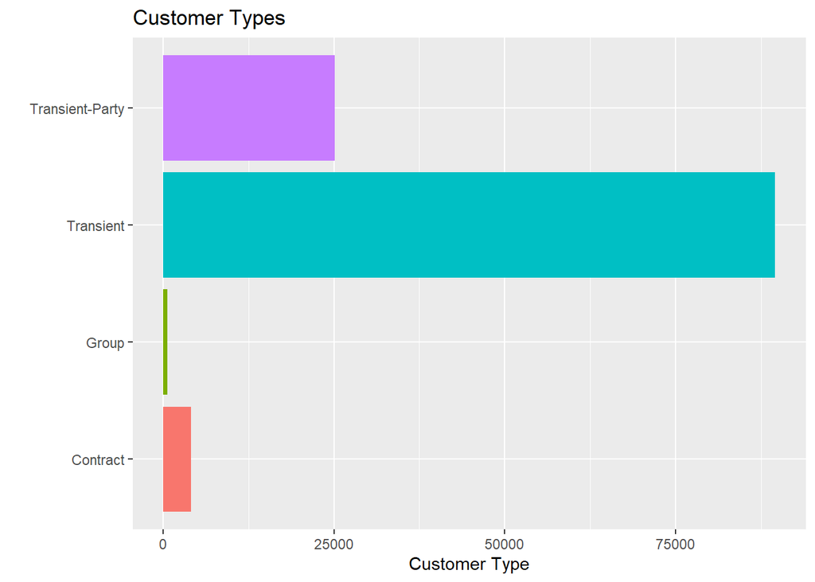

```r
hotels %>%
  count(customer_type, sort = TRUE) %>%
  plot_bar(., customer_type, n) +
  labs(x = "Customer Type", y = "",
       title = "Customer Types")
```

```r
hotels %>%
  count(customer_type, sort = TRUE)
```

| customer_type | n |
| --- | --- |
| Transient | 89613 |
| Transient-Party | 25124 |
| Contract | 4076 |
| Group | 577 |

### ADR

Average Daily Rate - this is the only value field we have related to cost in this dataset, with this we can take a look later on at how where some of the rate is derived from (such as the room type, market segment, meal type, etc.)

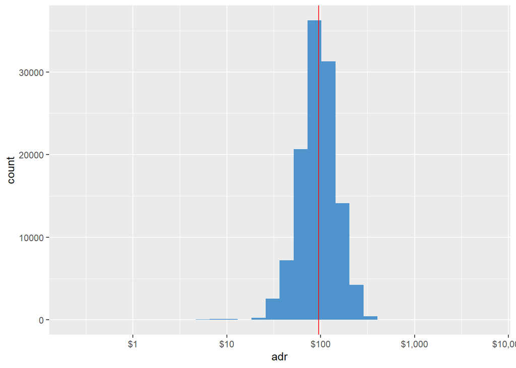

```r
adr_median <- hotels %>%
  filter(adr > 0) %>%
  summarise(median = median(adr))

hotels %>%
  filter(adr > 0) %>%
  plot_distribution(., adr, adr_median) +
  scale_x_log10(labels = dollar)
```

```r
# top 10 ADR values
hotels %>%
  arrange(desc(adr)) %>%
  head(10) %>%
  select(hotel, is_canceled, arrival_date, assigned_room_type, adr)
```

| hotel | is_canceled | arrival_date | assigned_room_type | adr |
| --- | --- | --- | --- | --- |
| City Hotel | 1 | 2016-03-25 | A | 5400.00 |
| City Hotel | 0 | 2017-05-09 | G | 510.00 |
| Resort Hotel | 0 | 2015-07-15 | C | 508.00 |
| City Hotel | 0 | 2016-12-31 | E | 451.50 |
| Resort Hotel | 1 | 2017-08-01 | A | 450.00 |
| Resort Hotel | 1 | 2017-08-13 | H | 437.00 |
| Resort Hotel | 0 | 2017-08-01 | G | 426.25 |
| Resort Hotel | 0 | 2017-08-17 | H | 402.00 |
| Resort Hotel | 0 | 2017-07-31 | H | 397.38 |
| Resort Hotel | 1 | 2017-08-09 | F | 392.00 |

# Market Segment Analysis and Impact

### Market Segment Breakdown

Checking out the top market segments of each hotel.

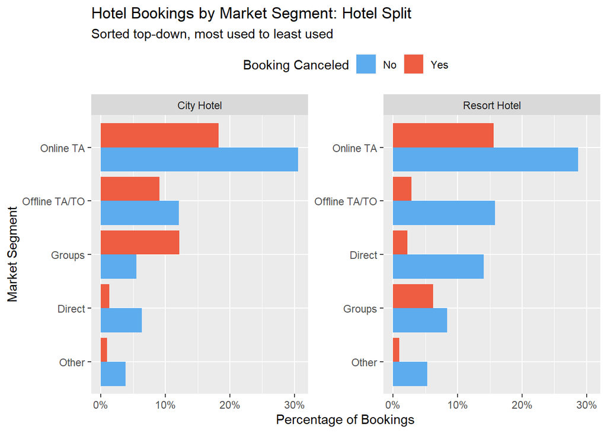

```r
# data manipulation for plotting
hotels_markets <- hotels %>%
  filter(market_segment != "Undefined") %>%
  mutate(market_segment = fct_lump(market_segment, 4)) %>%
  count(hotel, market_segment, is_canceled) %>%
  group_by(hotel) %>%
  mutate(total = sum(n),
         ratio = n / total,
         is_canceled = ifelse(is_canceled == 0, "No", "Yes")) %>%
  ungroup() %>%
  mutate(market_segment = reorder_within(market_segment, ratio, hotel))

hotels_markets %>%
  ggplot(aes(ratio, market_segment, fill = is_canceled)) +
  geom_col(position = "dodge") +
  labs(x = "Percentage of Bookings", y = "Market Segment",
       title = "Hotel Bookings by Market Segment: Hotel Split",
       subtitle = "Sorted top-down, most used to least used",
       fill = "Booking Canceled") +
  facet_wrap(~ hotel, scales = "free_y") +
  scale_x_continuous(labels = percent_format(accuracy = 1)) +
  scale_fill_manual(values = c("steelblue2", "tomato2")) +
  scale_y_reordered() +
  theme(legend.position = "top")
```

Looking at the results, we can see that the majority of people use travel agents (both online and offline) with direct being a close follow up for the resort hotel. We also can see that cancellations are quite proportionally high for the city hotel, especially for the group bookings which makes sense as there is a high chance for one individual out of a group to cause a cancellation due to external factors.

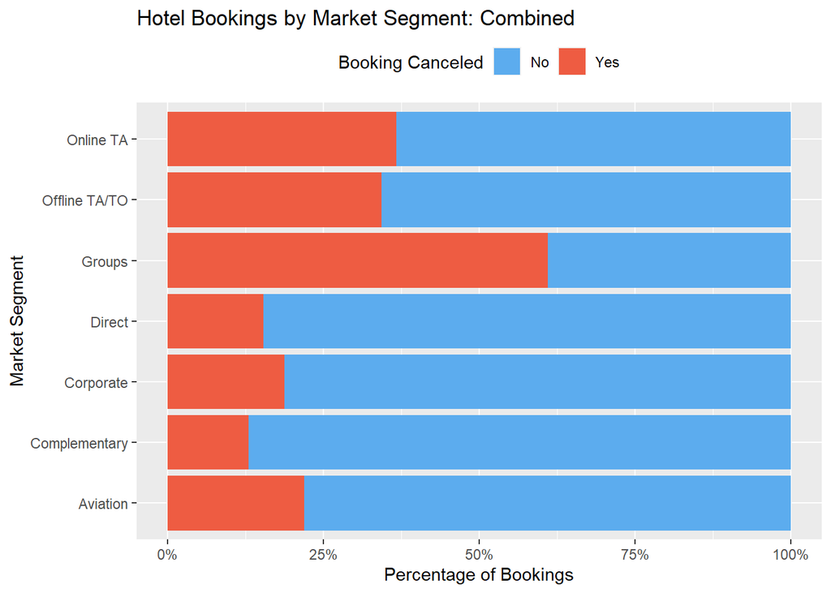

```r
hotels_markets <- hotels %>%
  filter(market_segment != "Undefined") %>%
  group_by(market_segment) %>%
  count(market_segment, is_canceled) %>%
  mutate(total = sum(n),
         ratio = n / total,
         is_canceled = ifelse(is_canceled == 0, "No", "Yes")) %>%
  arrange(desc(n))

# stacked column chart grouping all bookings
hotels_markets %>%
  ggplot(aes(market_segment, ratio, fill = is_canceled)) +
  geom_col() +
  labs(x = "Market Segment", y = "Percentage of Bookings",
     title = "Hotel Bookings by Market Segment: Combined",
     fill = "Booking Canceled") +
  scale_y_continuous(labels = percent_format(accuracy = 1)) +
  scale_x_reordered() +
  scale_fill_manual(values = c("steelblue2", "tomato2")) +
  theme(legend.position = "top") +
  coord_flip()
```

# Lead Time Analysis

Taking a look at the `lead_time` values, we can split the lead times into two categories, same day bookings and standard ahead of date bookings.

A few things I have in mind while reviewing the distributions, many of these apply to all distributions I’ll look at and not just lead-time specific:

- How extreme are outliers compared to the majority of the data’s distribution
- Check for any bimodal distributions or any cycles
- Would the cancellation vs. non-cancellation factor impact the distributions

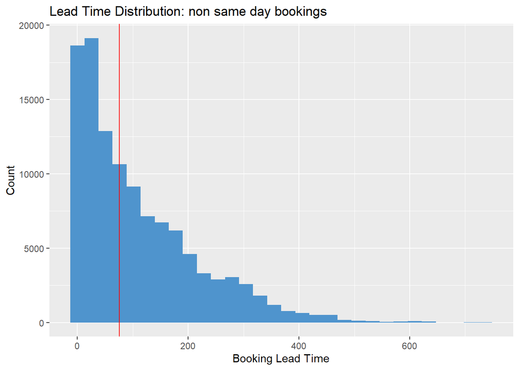

```r
# median for non 0 LT (lead time) bookings
nonzero_LT_median <- hotels %>%
  filter(lead_time > 0) %>%
  summarise(median = median(lead_time))

# for non same-day bookings, was does the lead time distribution look like
hotels %>%
  filter(lead_time > 0) %>%
  plot_distribution(., lead_time, nonzero_LT_median) +
  labs(x = "Booking Lead Time", y = "Count",
       title = "Lead Time Distribution: non same day bookings")
```

### Arrival date analysis:

Looking at the breakdown of arrival day-of-week by market segment first.

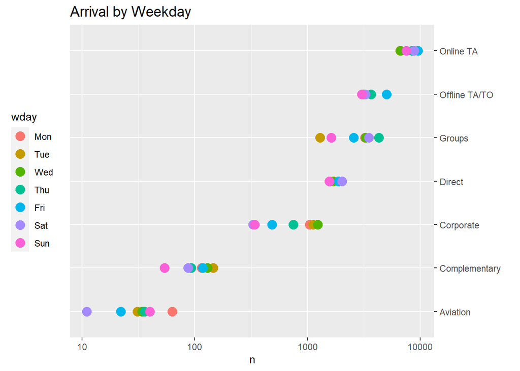

```r
# looking at the different market segments and arrival day of week for comparisons

hotels %>%
  mutate(wday = wday(arrival_date, label = TRUE, week_start = 1)) %>%
  filter(market_segment != "Undefined") %>%
  group_by(wday, market_segment) %>%
  count(wday) %>%
  ggplot(aes(market_segment, y= n, color= wday)) +
  geom_point(size=4) +
  theme(legend.position = "left",
        plot.title = element_text(size=14)) +
  coord_flip() +
  scale_x_discrete(position="to") +
  labs(x = "") +
  ggtitle("Arrival by Weekday") +
  scale_color_hue() +
  scale_y_log10()
```

Looking at the results we find:

- `Online TA`, `Offline TA/TO`, `Groups` appear to be the top three markets; TA = Travel Agent, TO = Tour Operators
- You can see that the most common day of week shifts from segment to segment with Friday being popular for `Online TA` and `Offline TA/TO` but Monday-Wednesday being more common for `Corporate` which makes sense as if you are working you’ll likely be staying during just the work week

### Breakdown by day of month

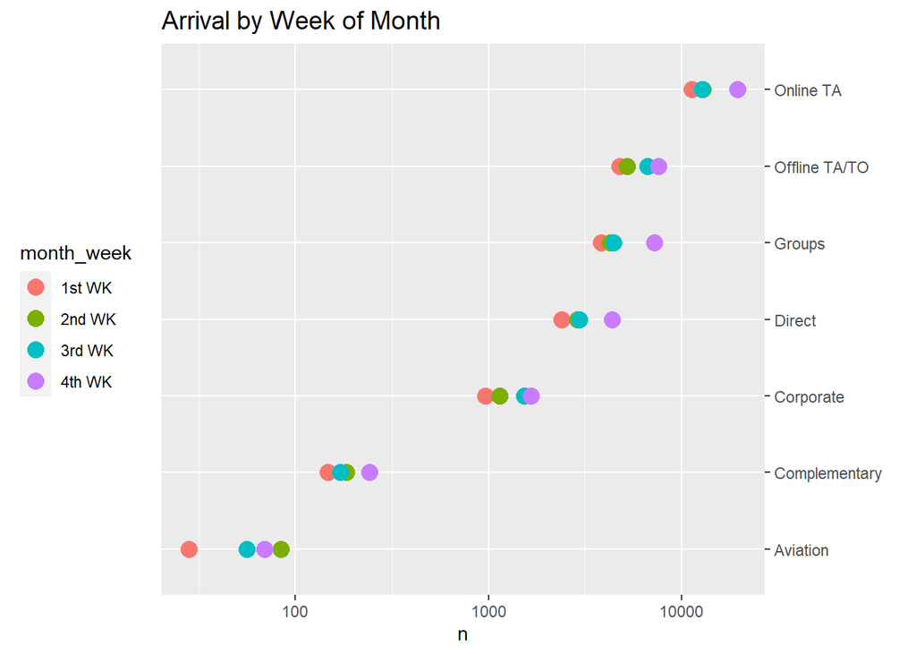

```r
hotels %>%
  mutate(month_week = case_when(arrival_date_day_of_month >= 21 ~ '4th WK',
                                arrival_date_day_of_month >= 14 ~ '3rd WK',
                                arrival_date_day_of_month >= 7 ~ '2nd WK',
                                arrival_date_day_of_month < 7 ~ '1st WK')) %>%
  filter(market_segment != "Undefined") %>%
  group_by(month_week, market_segment) %>%
  count(month_week) %>%
  ggplot(aes(market_segment, y= n, color= month_week)) +
  geom_point(size=4) +
  theme(legend.position = "left",
        plot.title = element_text(size=14)) +
  coord_flip() +
  scale_x_discrete(position="to") +
  labs(x = "") +
  ggtitle("Arrival by Week of Month") +
  scale_color_hue() +
  scale_y_log10()
```

Nothing too spread out for this plot, the main consistency is that the last week of the month is almost always the number one week, with `Aviation` having the second week as their most common. We can change this up a bit to see if any months in particular show trends of bookings.

# Bookings Time Series Analysis

First we’ll take a look at a single year available in the dataset which spans from July 1st, 2015 to August 31st, 2017. Looking at 2016 for both the city and resort hotels, we can make a few observations:

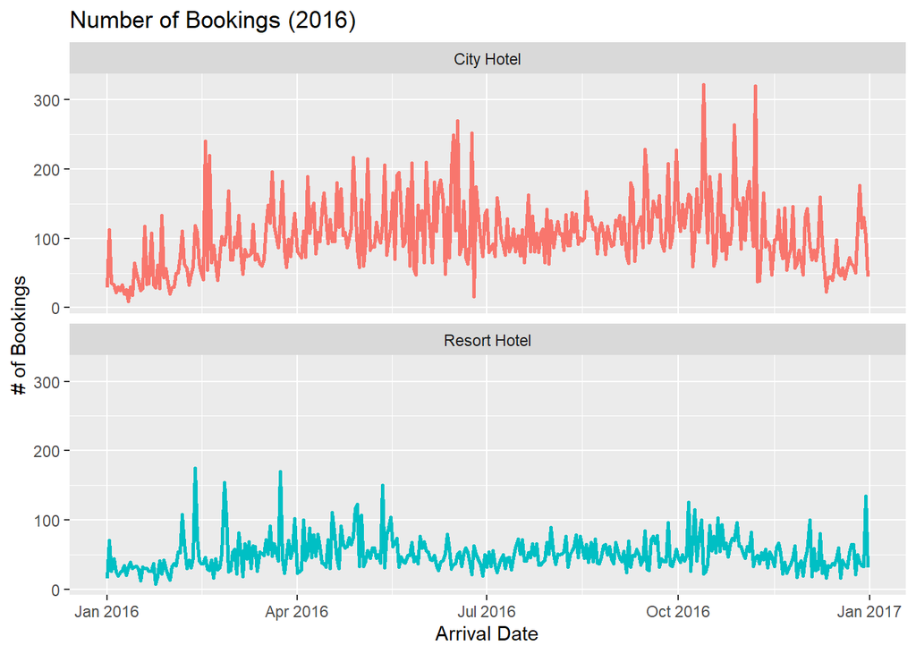

```r
hotels %>%
  filter(between(arrival_date, as.Date("2016-01-01"), as.Date("2016-12-31"))) %>%
  group_by(hotel, arrival_date, arrival_date_year) %>%
  summarise(count = n()) %>%
  ggplot(aes(arrival_date, count)) +
  geom_line(aes(color = hotel), size = 1) +
  facet_wrap(~ hotel, ncol = 1) +
  theme(legend.position = "none") +
    labs(x = "Arrival Date", y = "# of Bookings",
       title = "Number of Bookings (2016)")
```

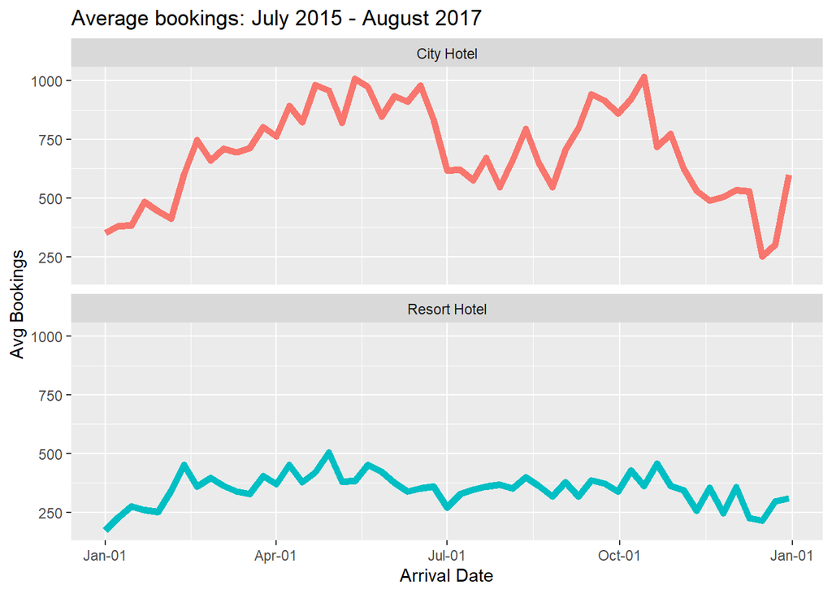

```r
hotels %>%
  group_by(hotel, arrival_date_year, arrival_date_week_number) %>%
  count() %>%
  group_by(hotel, arrival_date_week_number) %>%
  summarise(avg_bookings = mean(n)) %>%
  mutate(year_month = ymd("2000-01-01") + weeks(arrival_date_week_number - 1)) %>%
  ggplot(aes(year_month, avg_bookings)) +
  geom_line(aes(color = hotel), size = 2) +
  scale_x_date(date_labels = "%b-%d") +
  facet_wrap(~ hotel, ncol = 1) +
  theme(legend.position = "none") +
  labs(x = "Arrival Date", y = "Avg Bookings",
       title = "Average bookings: July 2015 - August 2017")
```

Overall this average over the time periods provided shows a bit more clearly the trends that each hotel has and how similar/different they can be. Both have a steady climb at the beginning of the year with Carnival bookings leading into a dip from July to September and a final increase at the end of the year for new years.

There is some divergence with the city hotel in the second half of the year having a large resurgence in bookings from the end of September to November which we’ll have to investigate further to identify what customers are driving this increase.